# R básico para ciencia de datos - Clase 3

Ph D. Stephanie Hereira-Pacheco

Universidad Autónoma de Tlaxcala

2026-05-21

## Estadísticos básicos en R — Clase 3

- Estadísticos descriptivos
- Gráficos descriptivos básicos
- Exploración de normalidad
- Correlación
- Regresión lineal
- ANOVA (1 vía) y prueba de Tukey
- ANOVA (2 vías)
- Otras pruebas
- Ejercicios

## Dataset de trabajo

Trabajaremos con `iris` — medidas de sépalos y pétalos de tres especies de flores.

```r
data(iris)
colnames(iris) <- c("Largo_Sepalo", "Ancho_Sepalo",
                    "Largo_Petalo", "Ancho_Petalo", "Especie")
str(iris)
```

```
'data.frame':   150 obs. of  5 variables:
 $ Largo_Sepalo: num  5.1 4.9 4.7 4.6 5 5.4 4.6 5 4.4 4.9 ...
 $ Ancho_Sepalo: num  3.5 3 3.2 3.1 3.6 3.9 3.4 3.4 2.9 3.1 ...
 $ Largo_Petalo: num  1.4 1.4 1.3 1.5 1.4 1.7 1.4 1.5 1.4 1.5 ...
 $ Ancho_Petalo: num  0.2 0.2 0.2 0.2 0.2 0.4 0.3 0.2 0.2 0.1 ...
 $ Especie     : Factor w/ 3 levels "setosa","versicolor",..: 1 1 1 1 1 1 1 1 1 1 ...
```

## Dataset de trabajo: las especies

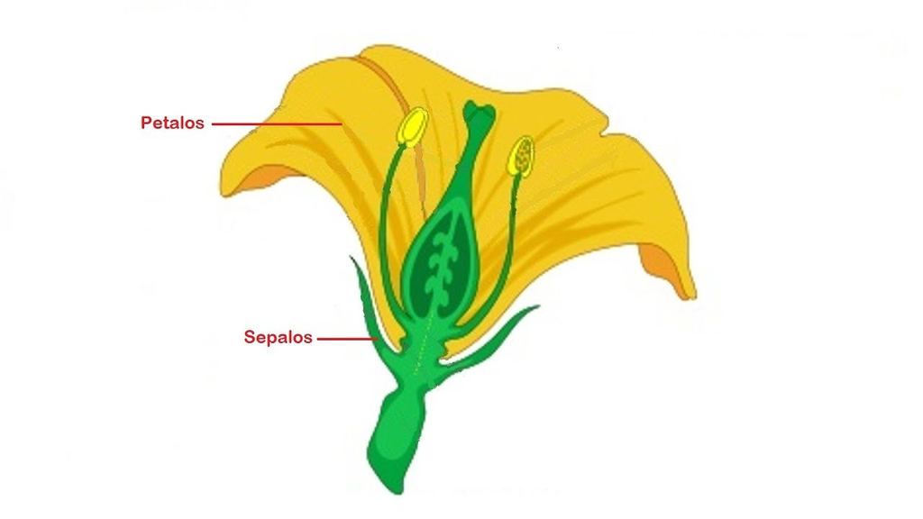

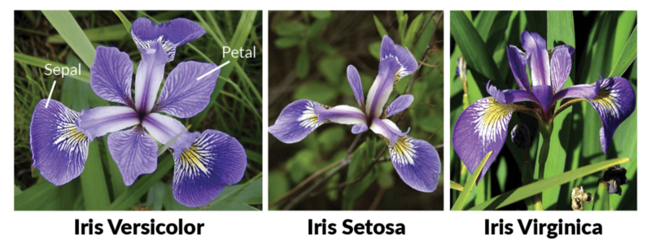

## Estadísticos descriptivos: `summary()`

`summary()` es el punto de partida — da el mínimo, máximo, promedio, mediana y cuartiles de cada variable:

```r
summary(iris)
```

```
  Largo_Sepalo    Ancho_Sepalo    Largo_Petalo    Ancho_Petalo
 Min.   :4.300   Min.   :2.000   Min.   :1.000   Min.   :0.100
 1st Qu.:5.100   1st Qu.:2.800   1st Qu.:1.600   1st Qu.:0.300
 Median :5.800   Median :3.000   Median :4.350   Median :1.300
 Mean   :5.843   Mean   :3.057   Mean   :3.758   Mean   :1.199
 3rd Qu.:6.400   3rd Qu.:3.300   3rd Qu.:5.100   3rd Qu.:1.800
 Max.   :7.900   Max.   :4.400   Max.   :6.900   Max.   :2.500
       Especie
 setosa    :50
 versicolor:50
 virginica :50
```

## Tendencia central

```r
mean(iris$Ancho_Sepalo)      # promedio
```

```
[1] 3.057333
```

```r
median(iris$Ancho_Sepalo)    # mediana
```

```
[1] 3
```

```r
min(iris$Ancho_Sepalo)
```

```
[1] 2
```

```r
max(iris$Ancho_Sepalo)
```

```
[1] 4.4
```

## Dispersión

```r
sd(iris$Ancho_Sepalo)        # desviación estándar
```

```
[1] 0.4358663
```

```r
var(iris$Ancho_Sepalo)       # varianza
```

```
[1] 0.1899794
```

**Tip**

La **desviación estándar** mide cuánto se alejan los datos del promedio. A mayor SD, más dispersos son los datos.

## Dispersión: cuartiles e IQR

```r
quantile(iris$Ancho_Sepalo, 0.25)   # primer cuartil (Q1)
```

```
25%
2.8
```

```r
quantile(iris$Ancho_Sepalo, 0.75)   # tercer cuartil (Q3)
```

```
75%
3.3
```

```r
quantile(iris$Ancho_Sepalo)         # todos los cuartiles a la vez
```

```
  0%  25%  50%  75% 100%
 2.0  2.8  3.0  3.3  4.4
```

```r
IQR(iris$Ancho_Sepalo)              # rango intercuartil
```

```
[1] 0.5
```

## Estadísticos para varias columnas

```r
colMeans(iris[, 1:4])
```

```
Largo_Sepalo Ancho_Sepalo Largo_Petalo Ancho_Petalo
    5.843333     3.057333     3.758000     1.199333
```

**Tip**

`colMeans()` calcula el promedio de todas las columnas numéricas de un golpe. Para la desviación estándar, usa `sd(iris$columna)` en la columna que necesites.

## Gráficos descriptivos: histograma

```r
hist(iris$Ancho_Sepalo, main = "Distribución ancho del sépalo",
     xlab = "Ancho (cm)", col = "steelblue")
```

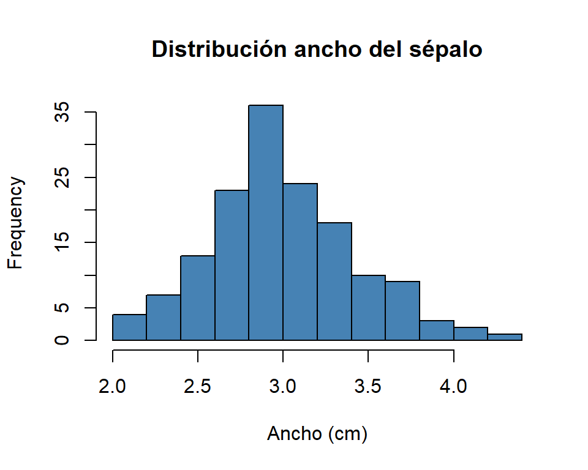

## Gráficos descriptivos: boxplot

```r
boxplot(Largo_Sepalo ~ Especie, data = iris,
        xlab = "Especie", ylab = "Largo sépalo (cm)",
        col = c("orchid", "lightblue", "lightgreen"))
```

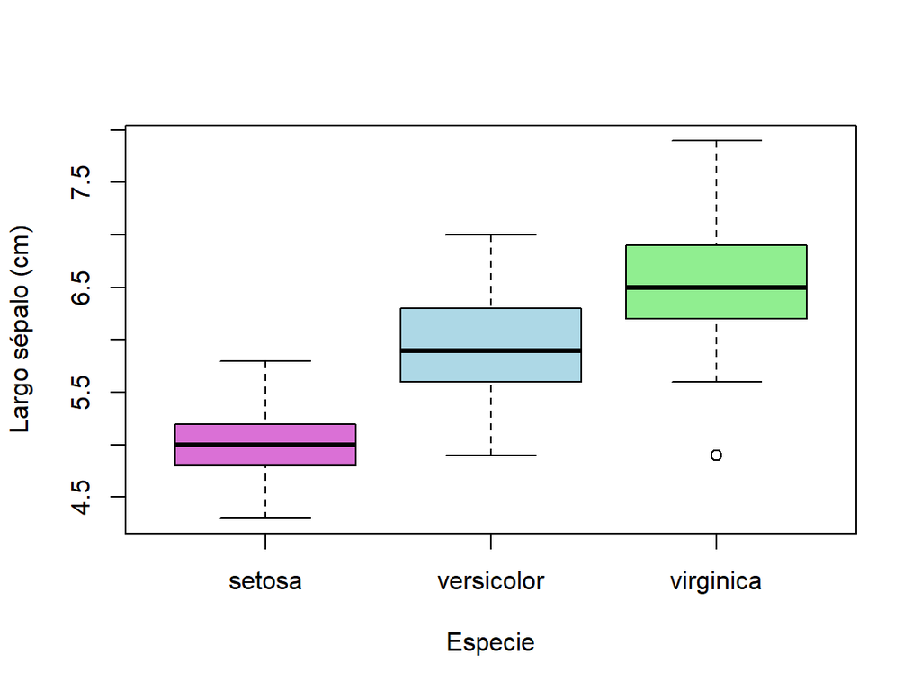

## ¿Cómo leer un boxplot?

**Note**

- La **línea del medio** = mediana
- La **caja** = rango intercuartil (Q1 a Q3)
- Los **bigotes** llegan hasta 1.5 × IQR
- Los **puntos** fuera de los bigotes = valores atípicos (*outliers*)

## Exploración de normalidad

La prueba de **Shapiro-Wilk** verifica si los datos siguen una distribución normal:

```r
shapiro.test(iris$Ancho_Sepalo)
```

```
    Shapiro-Wilk normality test

data:  iris$Ancho_Sepalo
W = 0.98492, p-value = 0.1012
```

**Note**

**H₀:** los datos son normales.

- **p-value > 0.05** → no rechazamos H₀ → **los datos son normales**
- **p-value < 0.05** → los datos **no** son normales → usar pruebas no paramétricas

## Normalidad: gráfico Q-Q

```r
qqnorm(iris$Ancho_Sepalo, main = "Q-Q plot - Ancho Sépalo")
qqline(iris$Ancho_Sepalo, col = "red")
```

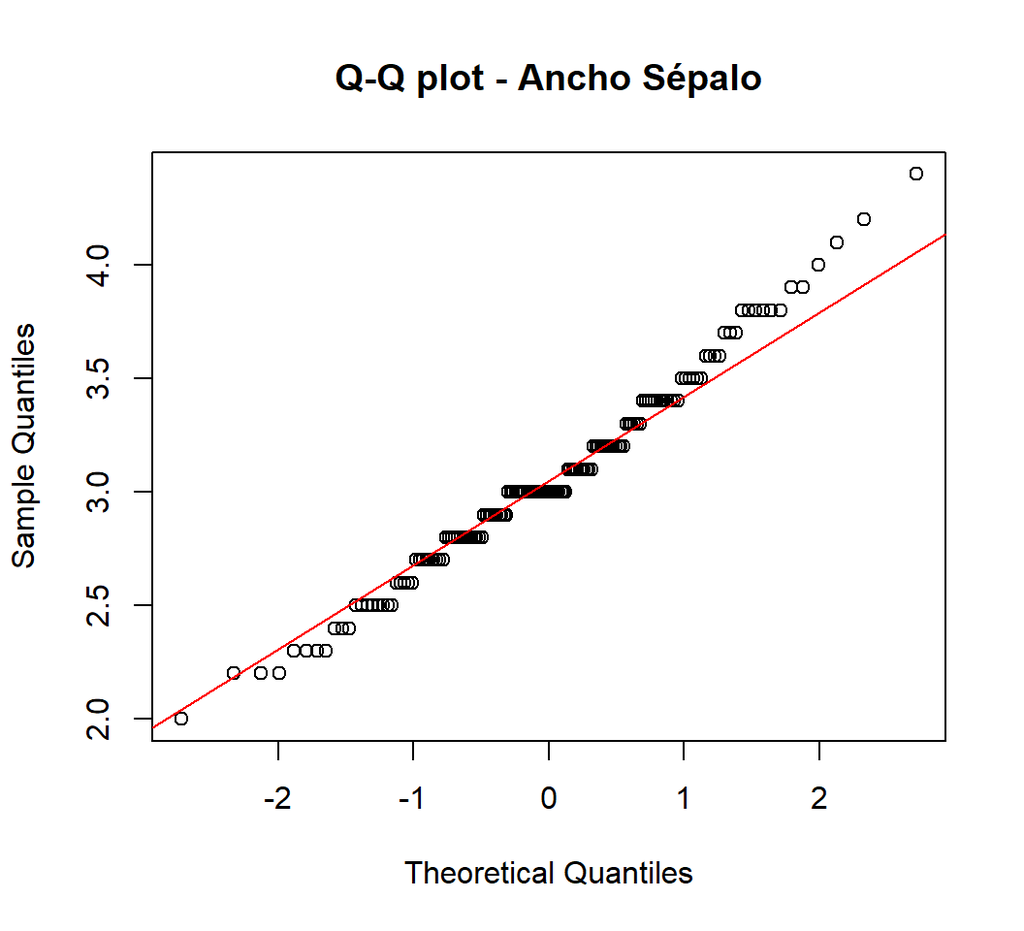

## Estructura de los modelos en R

modelo `<-` lm(**Respuesta** `~` **Factor**, data = **Datos**)

**A la izquierda del `~`**

Variable **numérica / dependiente** — lo que mides en el laboratorio

**A la derecha del `~`**

Variable **categórica / independiente** — el factor o grupo a comparar

**Important**

En la fórmula siempre modificarán tres cosas: **Respuesta**, **Factor** y **Datos**.

## Regresión lineal

Describe la relación entre dos variables: **y = a·x + b**

```r
#            Respuesta   ~ Factor        data = Datos
modelo <- lm(Ancho_Petalo ~ Largo_Petalo, data = iris)
summary(modelo)
```

```
Call:
lm(formula = Ancho_Petalo ~ Largo_Petalo, data = iris)

Residuals:
     Min       1Q   Median       3Q      Max
-0.56515 -0.12358 -0.01898  0.13288  0.64272

Coefficients:
              Estimate Std. Error t value Pr(>|t|)
(Intercept)  -0.363076   0.039762  -9.131  4.7e-16 ***
Largo_Petalo  0.415755   0.009582  43.387  < 2e-16 ***
---
Signif. codes:  0 '***' 0.001 '**' 0.01 '*' 0.05 '.' 0.1 ' ' 1

Residual standard error: 0.2065 on 148 degrees of freedom
Multiple R-squared:  0.9271,    Adjusted R-squared:  0.9266
F-statistic:  1882 on 1 and 148 DF,  p-value: < 2.2e-16
```

## Regresión lineal: interpretar

**Note**

Del `summary(modelo)`:

- **Intercepto** = −0.363, **pendiente** = 0.416
- Ecuación: `Ancho_Petalo = 0.416 × Largo_Petalo − 0.363`
- **p-values < 0.05** → la relación es significativa
- **R² ajustado ≈ 0.92** → el modelo explica el **92%** de la variación

## ANOVA (1 vía)

Compara las **medias de más de dos grupos**.

```r
#                   Respuesta  ~ Factor  data = Datos
modelo_anova <- lm(Ancho_Sepalo ~ Especie, data = iris)
anova(modelo_anova)
```

```
Analysis of Variance Table

Response: Ancho_Sepalo
           Df Sum Sq Mean Sq F value    Pr(>F)
Especie     2 11.345  5.6725   49.16 < 2.2e-16 ***
Residuals 147 16.962  0.1154
---
Signif. codes:  0 '***' 0.001 '**' 0.01 '*' 0.05 '.' 0.1 ' ' 1
```

**Note**

**p-value << 0.05** → las medias **son diferentes** entre al menos dos especies.

## Prueba de Tukey

ANOVA dice que hay diferencias, pero no dice *entre cuáles grupos*. Tukey lo determina:

```r
fm <- aov(modelo_anova)
TukeyHSD(fm, "Especie", ordered = TRUE)
```

```
  Tukey multiple comparisons of means
    95% family-wise confidence level
    factor levels have been ordered

Fit: aov(formula = modelo_anova)

$Especie
                      diff        lwr       upr     p adj
virginica-versicolor 0.204 0.04314472 0.3648553 0.0087802
setosa-versicolor    0.658 0.49714472 0.8188553 0.0000000
setosa-virginica     0.454 0.29314472 0.6148553 0.0000000
```

## Tukey: interpretar

**Note**

Cada fila compara un par de especies:

- **p adj < 0.05** → esas dos especies **son significativamente diferentes**
- **p adj > 0.05** → no hay diferencia significativa entre ese par

## ANOVA (2 vías)

Estudia el efecto de **dos factores** sobre una variable.

**Note**

Usaremos `ToothGrowth`: efecto de la dosis (`dose`) y el suplemento (`supp`) sobre el crecimiento dental (`len`).

## ANOVA (2 vías): los datos

`dose` está guardada como número — la convertiremos a factor:

```r
data("ToothGrowth")
str(ToothGrowth)
```

```
'data.frame':   60 obs. of  3 variables:
 $ len : num  4.2 11.5 7.3 5.8 6.4 10 11.2 11.2 5.2 7 ...
 $ supp: Factor w/ 2 levels "OJ","VC": 2 2 2 2 2 2 2 2 2 2 ...
 $ dose: num  0.5 0.5 0.5 0.5 0.5 0.5 0.5 0.5 0.5 0.5 ...
```

## ANOVA (2 vías): preparar los datos

```r
ToothGrowth$dose <- factor(ToothGrowth$dose,
                           levels = c(0.5, 1, 2),
                           labels = c("D0.5", "D1", "D2"))
head(ToothGrowth)
```

```
   len supp dose
1  4.2   VC D0.5
2 11.5   VC D0.5
3  7.3   VC D0.5
4  5.8   VC D0.5
5  6.4   VC D0.5
6 10.0   VC D0.5
```

## ANOVA (2 vías): modelo aditivo

Efectos **independientes** de cada factor:

```r
anova1 <- aov(len ~ supp + dose, data = ToothGrowth)
summary(anova1)
```

```
            Df Sum Sq Mean Sq F value   Pr(>F)
supp         1  205.4   205.4   14.02 0.000429 ***
dose         2 2426.4  1213.2   82.81  < 2e-16 ***
Residuals   56  820.4    14.7
---
Signif. codes:  0 '***' 0.001 '**' 0.01 '*' 0.05 '.' 0.1 ' ' 1
```

## ANOVA (2 vías): modelo con interacción

El efecto de un factor **depende del otro**:

```r
anova2 <- aov(len ~ supp * dose, data = ToothGrowth)
summary(anova2)
```

```
            Df Sum Sq Mean Sq F value   Pr(>F)
supp         1  205.4   205.4  15.572 0.000231 ***
dose         2 2426.4  1213.2  92.000  < 2e-16 ***
supp:dose    2  108.3    54.2   4.107 0.021860 *
Residuals   54  712.1    13.2
---
Signif. codes:  0 '***' 0.001 '**' 0.01 '*' 0.05 '.' 0.1 ' ' 1
```

**Note**

La fila `supp:dose` con **p < 0.05** confirma **interacción**: el efecto de la dosis cambia según el tipo de suplemento.

## ANOVA (2 vías): gráfico de interacción

Las líneas **no paralelas** confirman visualmente la interacción:

```r
interaction.plot(x.factor   = ToothGrowth$dose,
                 trace.factor = ToothGrowth$supp,
                 response   = ToothGrowth$len,
                 col = c("steelblue", "tomato"), lwd = 2,
                 xlab = "Dosis", ylab = "Longitud media",
                 trace.label = "Suplemento")
```

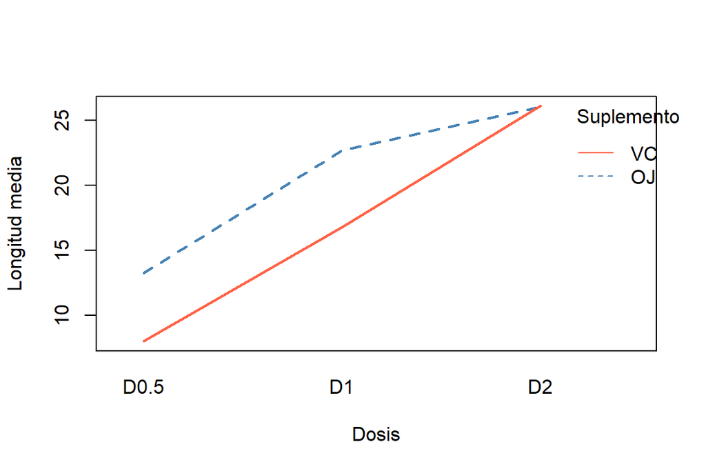

## Otras pruebas: `t.test()`

Para comparar **dos grupos** cuando los datos son normales:

```r
t.test(len ~ supp, data = ToothGrowth)
```

```
    Welch Two Sample t-test

data:  len by supp
t = 1.9153, df = 55.309, p-value = 0.06063
alternative hypothesis: true difference in means between group OJ and group VC is not equal to 0
95 percent confidence interval:
 -0.1710156  7.5710156
sample estimates:
mean in group OJ mean in group VC
        20.66333         16.96333
```

## Otras pruebas: `wilcox.test()`

Alternativa **no paramétrica** al t.test (cuando los datos no son normales):

```r
wilcox.test(len ~ supp, data = ToothGrowth)
```

```
    Wilcoxon rank sum test with continuity correction

data:  len by supp
W = 575.5, p-value = 0.06449
alternative hypothesis: true location shift is not equal to 0
```

## Otras pruebas: `kruskal.test()`

Alternativa no paramétrica al ANOVA — más de dos grupos:

```r
kruskal.test(len ~ dose, data = ToothGrowth)
```

```
    Kruskal-Wallis rank sum test

data:  len by dose
Kruskal-Wallis chi-squared = 40.669, df = 2, p-value = 1.475e-09
```

**Note**

**p-value < 0.05** → hay diferencias significativas entre al menos dos grupos de dosis.

## Referencia: ¿qué prueba usar?

| Situación | Datos normales | Datos no normales |
| --- | --- | --- |
| 2 grupos independientes | `t.test()` | `wilcox.test()` |
| 2 grupos pareados | `t.test(paired=TRUE)` | `wilcox.test(paired=TRUE)` |
| Más de 2 grupos | `anova()` | `kruskal.test()` |
| 2 factores | `aov(y ~ a + b)` | — |
| 2 factores con interacción | `aov(y ~ a * b)` | — |

## Correlación: `cor.test()`

¿Existe relación entre el largo y el ancho del pétalo?

```r
cor.test(iris$Largo_Petalo, iris$Ancho_Petalo)
```

```
    Pearson's product-moment correlation

data:  iris$Largo_Petalo and iris$Ancho_Petalo
t = 43.387, df = 148, p-value < 2.2e-16
alternative hypothesis: true correlation is not equal to 0
95 percent confidence interval:
 0.9490525 0.9729853
sample estimates:
      cor
0.9628654
```

## Correlación: gráfico

```r
plot(iris$Largo_Petalo, iris$Ancho_Petalo,
     xlab = "Largo pétalo (cm)", ylab = "Ancho pétalo (cm)",
     pch = 19, col = "steelblue")
abline(lm(Ancho_Petalo ~ Largo_Petalo, data = iris),
       col = "tomato", lwd = 2)
```

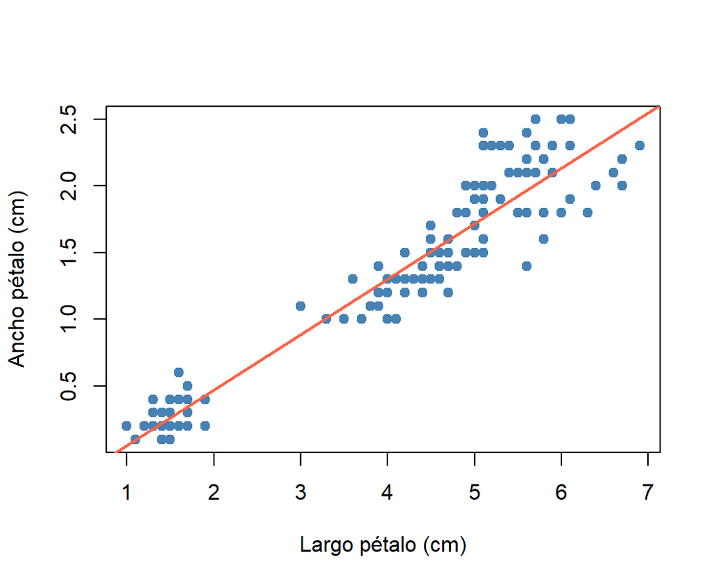

## Correlación: interpretar

**Note**

- **cor ≈ 0.96** → correlación positiva muy fuerte
- **p-value < 0.05** → la correlación es significativa
- Signo **+** = cuando uno sube el otro también; signo **−** = cuando uno sube el otro baja

## Correlación: ¿qué tan fuerte es?

| Valor absoluto | Interpretación |
| --- | --- |
| 0.9 – 1.0 | Muy fuerte |
| 0.7 – 0.9 | Fuerte |
| 0.5 – 0.7 | Moderada |
| < 0.5 | Débil |

## Ejercicios

**Note**

Usa el dataset `iris` — ya está cargado desde el inicio de la clase.

1. Calcula el promedio, mediana y desviación estándar de `Ancho_Sepalo`.
2. Haz un histograma de `Ancho_Sepalo`. ¿Tiene forma de campana?
3. Haz un boxplot de `Ancho_Sepalo` por `Especie`. ¿Cuál especie tiene la mediana más alta?
4. Aplica `shapiro.test()` a `Ancho_Sepalo`. ¿Son normales los datos?

## Ejercicios (cont.)

5. Corre un ANOVA de `Ancho_Sepalo ~ Especie`. ¿Hay diferencias entre especies?
6. Aplica `TukeyHSD()` al modelo anterior. ¿Entre cuáles pares de especies hay diferencias?
7. Calcula la correlación entre `Largo_Petalo` y `Ancho_Petalo`. ¿Es significativa? ¿Positiva o negativa?

## Soluciones: ejercicio 1

**1.** Estadísticos descriptivos:

```r
mean(iris$Ancho_Sepalo)
```

```
[1] 3.057333
```

```r
median(iris$Ancho_Sepalo)
```

```
[1] 3
```

```r
sd(iris$Ancho_Sepalo)
```

```
[1] 0.4358663
```

## Soluciones: ejercicio 2

**2.** Histograma:

```r
hist(iris$Ancho_Sepalo, main = "Distribución de Ancho_Sepalo",
     xlab = "Ancho (cm)", col = "steelblue")
```

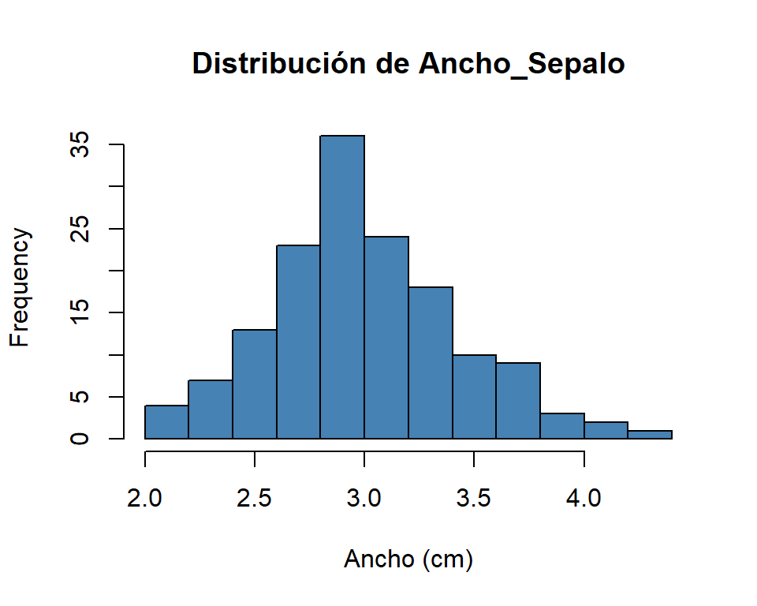

## Soluciones: ejercicio 3

**3.** Boxplot por especie:

```r
boxplot(Ancho_Sepalo ~ Especie, data = iris,
        col = c("orchid", "lightblue", "lightgreen"),
        xlab = "Especie", ylab = "Ancho sépalo (cm)")
```

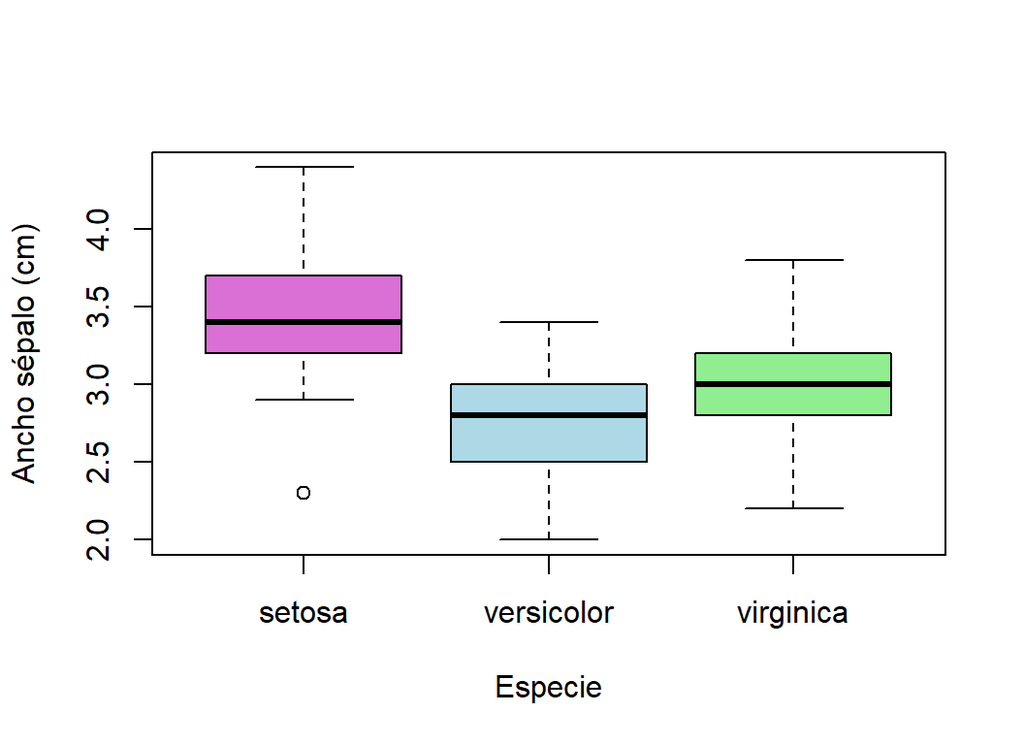

## Soluciones: ejercicio 4

**4.** Prueba de normalidad:

```r
shapiro.test(iris$Ancho_Sepalo)
```

```
    Shapiro-Wilk normality test

data:  iris$Ancho_Sepalo
W = 0.98492, p-value = 0.1012
```

**Note**

p-value > 0.05 → los datos son normales.

## Soluciones: ejercicio 5

**5.** ANOVA `Ancho_Sepalo ~ Especie`:

```r
mod <- lm(Ancho_Sepalo ~ Especie, data = iris)
anova(mod)
```

```
Analysis of Variance Table

Response: Ancho_Sepalo
           Df Sum Sq Mean Sq F value    Pr(>F)
Especie     2 11.345  5.6725   49.16 < 2.2e-16 ***
Residuals 147 16.962  0.1154
---
Signif. codes:  0 '***' 0.001 '**' 0.01 '*' 0.05 '.' 0.1 ' ' 1
```

## Soluciones: ejercicio 6

**6.** Prueba de Tukey:

```r
TukeyHSD(aov(mod), "Especie", ordered = TRUE)
```

```
  Tukey multiple comparisons of means
    95% family-wise confidence level
    factor levels have been ordered

Fit: aov(formula = mod)

$Especie
                      diff        lwr       upr     p adj
virginica-versicolor 0.204 0.04314472 0.3648553 0.0087802
setosa-versicolor    0.658 0.49714472 0.8188553 0.0000000
setosa-virginica     0.454 0.29314472 0.6148553 0.0000000
```

## Soluciones: ejercicio 7

**7.** Correlación `Largo_Petalo` ~ `Ancho_Petalo`:

```r
cor.test(iris$Largo_Petalo, iris$Ancho_Petalo)
```

```
    Pearson's product-moment correlation

data:  iris$Largo_Petalo and iris$Ancho_Petalo
t = 43.387, df = 148, p-value < 2.2e-16
alternative hypothesis: true correlation is not equal to 0
95 percent confidence interval:
 0.9490525 0.9729853
sample estimates:
      cor
0.9628654
```

## Referencias

- Irizarry, R.A. (2019). *Introduction to Data Science*. rafalab.dfci.harvard.edu/dsbook
- Wickham, H. & Grolemund, G. (2017). *R for Data Science*. r4ds.had.co.nz
- Kassambara, A. (2017). *Practical Statistics in R*. sthda.com
- CRAN — Comprehensive R Archive Network: cran.r-project.org

R básico para ciencia de datos · UAT 2026